# Assignment 2

Henrik Olaussen

2023-08-29

## a)

### (i)

In a mixture of factors analyzers-model, the distribution of the i’th observation $Y_i$ is modeled by:

$$Y_j = \mu_i + B_i U_{ij} + e_{ij}, \quad i = 1,2,...,g, \quad j =
1,2,...,n$$

The final model has the form:

$$f(\mathbf{y}, \Psi) = \sum^g_{i=1} \pi_i\phi(\textbf{y}; \mu_i,
\Sigma_i)$$
where:
$$\Sigma_i = B_i B_i^T + D_i$$
In our case, we are going to fit models with g = 3 components and q = 1,2,3,4,5 and 6 factors. In the output from the 6 different mfa models, mu_i holds the values of the i’th component mean. The pi_i-values are the mixture proportions $\pi_i$, and B holds the factor loading contained in the matrix $B \in \mathbb{R}^{p \times q}$ from the model above. Lastly, “diag D” holds the values on the diagonal matrix $D$, where $D_i$ give the variance of the different $e_{ij}$ ($i = 1,2,..,g$), respectively. $U_{ij} \in \mathbb{R}^q$ holds the factors.

### (ii)

On the other hand, we have the MCFA model. The MCFA approach provides a greater reduction in the number of parameters compared to MFA. In this case, we fit the usual model $f(\textbf{y}, \Psi)$, but with the following restrictions:

$$\mathbf{ \mu }_i = A \mathbf{\xi}_i$$
and

$$\Sigma_i = A\Omega_iA^T + D$$

where $A \in \mathbb{R}^{p \times q}$, $\xi \in \mathbb{R}^q$ (xi_i in the mcfa output), $\Omega_i \in \mathbb{R}^{q \times q}$ and $D \in \mathbb{R}^{p \times p}$. $\Omega_i$ is a positive definite symmetric matrix, and $D$ a diagonal matrix. $A$ holds the loadings on the q unobservable factors. Moreover, the i’th component distribution of $Y_j$ is modeled by:

$$Y_j = AU_{ij} + e_{ij}$$
with probability $pi_i$ for $i = 1,2,..,g$, $j = 1,...,n$. The factors $U_{i1},..,U_{in}$ are distributed independently $N(\xi_i, \Omega_i)$, independently of $e_{ij}$ which again are distributed independently $N(0, D)$.

## b)

Before we can fit the models, we have to load the data:

```r
wine <- read.table('wine.data',sep=',')
wine_2 <- subset(wine, select = -c(1)) #exclude labels
```

The dataset has n = 178 observations.

#### (i)

Furthermore, we can now fit the 12 different models. This is done through a for-loop below:

```r
mfa.models = list()
mcfa.models = list()

for (q in 1:6) {
  mfa.models[[q]] = mfa(wine_2, g = 3, q)
  mcfa.models[[q]] = mcfa(wine_2, g = 3, q, itmax = 200, init_method = "eigen-A")
}
```

Firstly, the output from the different mfa models can be seen below. What each output parameter mean is briefly explained in a(i).

q = 1:

```r
mfa.models[[1]]
```

```
## Call:
## mfa(Y = wine_2, g = 3, q = q)
##
## Coefficients:
## pi_i :  0.276 0.412 0.312
##
## mu_1:
##  [1]  13.1491419   3.3358373   2.4327961  21.4166540  99.0185554   1.6794178
##  [7]   0.7999904   0.4510680   1.1604786   7.3354455   0.6871044   1.6900655
## [13] 626.9247308
## mu_2:
##  [1]  12.3074619   1.9694022   2.2714350  20.2290502  95.4121883   2.2850799
##  [7]   2.1182699   0.3593908   1.6464846   3.1133242   1.0563056   2.8222172
## [13] 531.2725629
## mu_3:
##  [1]   13.7843515    1.9350991    2.4333378   16.8223176  106.0996694
##  [6]    2.8540411    3.0012279    0.2860378    1.8989680    5.6079248
## [11]    1.0665043    3.1504780 1137.9637170
##
##  B:
##              [,1]
## V2   -0.08086141
## V3   -0.04358633
## V4   -0.07406263
## V5   -0.57329431
## V6   -2.21765941
## V7   -0.33813737
## V8   -0.46808539
## V9    0.02433175
## V10  -0.27776954
## V11  -0.60242482
## V12   0.01342258
## V13  -0.15359700
## V14 -16.96177028
## diag D:
##  [1] 2.533352e-01 8.573634e-01 6.303027e-02 7.291611e+00 1.774591e+02
##  [6] 7.299125e-02 5.765007e-02 1.081530e-02 1.665731e-01 1.896447e+00
## [11] 2.383952e-02 1.341545e-01 2.750869e+04
```

q = 2:

```r
mfa.models[[2]]
```

```
## Call:
## mfa(Y = wine_2, g = 3, q = q)
##
## Coefficients:
## pi_i :  0.276 0.394 0.33
##
## mu_1:
##  [1]  13.1492489   3.3354394   2.4330359  21.4157316  99.0423328   1.6791255
##  [7]   0.7989321   0.4507138   1.1601192   7.3374545   0.6867980   1.6896335
## [13] 627.1191444
## mu_2:
##  [1]  12.2702540   1.9471351   2.2438683  20.2146376  94.6129067   2.2725207
##  [7]   2.1107819   0.3566525   1.6510253   3.0826743   1.0563619   2.8163828
## [13] 520.8512302
## mu_3:
##  [1]   13.7498532    1.9652770    2.4575311   17.0254762  106.4623450
##  [6]    2.8379848    2.9620837    0.2936621    1.8797207    5.5123836
## [11]    1.0657768    3.1389700 1117.6003883
##
##  B:
##             [,1]         [,2]
## V2   0.10973359 -0.042872420
## V3  -0.01632802  0.097115727
## V4  -0.02769057  0.248527223
## V5  -0.21122553  1.896757652
## V6   1.08003351  2.757370808
## V7   0.32293946  0.100340486
## V8   0.44388708  0.169443966
## V9  -0.03909625  0.021471921
## V10  0.28693895  0.047974040
## V11  0.63945087  0.115008589
## V12 -0.01600510  0.005368429
## V13  0.13989418  0.064497390
## V14 25.47955306 -0.452019022
## diag D:
##  [1] 2.399946e-01 8.506331e-01 2.378812e-03 4.212130e+00 1.686728e+02
##  [6] 7.303947e-02 5.905562e-02 9.688353e-03 1.609700e-01 1.881154e+00
## [11] 2.371948e-02 1.346659e-01 2.855286e+04
```

q = 3:

```r
mfa.models[[3]]
```

```
## Call:
## mfa(Y = wine_2, g = 3, q = q)
##
## Coefficients:
## pi_i :  0.332 0.271 0.396
##
## mu_1:
##  [1]   13.7401473    1.9855817    2.4592279   17.2145028  106.8335227
##  [6]    2.8484449    2.9842589    0.2885035    1.9025514    5.5093196
## [11]    1.0682862    3.1636878 1118.6083052
## mu_2:
##  [1]  13.1550386   3.3850285   2.4340567  21.4721004  98.4393464   1.6813022
##  [7]   0.7915674   0.4554784   1.1651409   7.3840317   0.6844869   1.7009855
## [13] 625.8605512
## mu_3:
##  [1]  12.2750232   1.9120717   2.2425524  20.0520650  94.6894636   2.2517571
##  [7]   2.0765899   0.3592059   1.6213032   3.0868002   1.0515118   2.7727923
## [13] 518.2428647
##
##  B:
##              [,1]          [,2]        [,3]
## V2   -0.16320957  -0.031044342  0.07881484
## V3    0.19107671  -0.007175472 -0.22851351
## V4    0.14454907  -0.202279550  0.03686336
## V5    1.32594188  -1.389377542 -0.21726995
## V6   -0.22498645  -2.985870306  2.55413788
## V7   -0.17122651  -0.224317757 -0.17769235
## V8   -0.21569406  -0.331404752 -0.24366342
## V9    0.03151433  -0.006158487  0.02428965
## V10  -0.18972163  -0.167103932 -0.13211267
## V11  -0.88047379  -0.597386277  0.45668161
## V12   0.01748441   0.005881609  0.00569385
## V13   0.02147367  -0.069490117 -0.23921071
## V14 -47.76179858 -17.472208797 56.87730816
## diag D:
##  [1] 2.247243e-01 7.414614e-01 1.432529e-03 4.439644e+00 1.600632e+02
##  [6] 7.354249e-02 5.667200e-02 9.610304e-03 1.625424e-01 9.271402e-01
## [11] 2.376455e-02 1.020871e-01 2.219069e+04
```

q = 4:

```r
mfa.models[[4]]
```

```
## Call:
## mfa(Y = wine_2, g = 3, q = q)
##
## Coefficients:
## pi_i :  0.394 0.276 0.33
##
## mu_1:
##  [1]  12.2873992   1.9338118   2.2377737  20.2047224  93.9836474   2.2710274
##  [7]   2.1007118   0.3665026   1.6328696   3.1003055   1.0572407   2.7959028
## [13] 518.2899555
## mu_2:
##  [1]  13.1250224   3.3068796   2.4426582  21.4158151 100.0084516   1.6762926
##  [7]   0.7868112   0.4412462   1.1623780   7.2875046   0.6886076   1.6958077
## [13] 629.9857269
## mu_3:
##  [1]   13.746426    2.005397    2.456309   17.045167  106.378471    2.840600
##  [7]    2.981768    0.290013    1.898766    5.528674    1.063079    3.157091
## [13] 1116.875396
##
##  B:
##               [,1]          [,2]         [,3]         [,4]
## V2   -0.029230994  -0.183341154  0.002407648 -0.060000200
## V3    0.124397666   0.245633204 -0.167058135 -0.422387923
## V4   -0.031359524   0.055116719 -0.232124932  0.069459034
## V5   -0.173712070   0.614190053 -1.834276005  0.093599275
## V6   -2.929756351  -0.189442537 -1.285286894  3.366687095
## V7   -0.320395317  -0.025788821 -0.054742145 -0.053279553
## V8   -0.439845356  -0.024117476 -0.111821370 -0.081965603
## V9    0.043873403  -0.009351766 -0.035749569  0.008365721
## V10  -0.265309044  -0.058317445 -0.017163851 -0.076888074
## V11  -0.401475536  -1.367581574 -0.370621642 -0.281275484
## V12  -0.009535573   0.015015810  0.018427558  0.087752591
## V13  -0.146874379   0.128048726 -0.030198176 -0.079425135
## V14 -24.128926928 -55.604727694  9.033368817 50.737808772
## diag D:
##  [1] 2.289667e-01 5.989691e-01 1.269990e-03 4.106736e+00 1.536073e+02
##  [6] 7.611062e-02 5.106955e-02 8.587341e-03 1.630672e-01 1.416621e-01
## [11] 1.604379e-02 1.129468e-01 2.270593e+04
```

q = 5:

```r
mfa.models[[5]]
```

```
## Call:
## mfa(Y = wine_2, g = 3, q = q)
##
## Coefficients:
## pi_i :  0.329 0.369 0.302
##
## mu_1:
##  [1]   13.7491560    2.0039293    2.4553125   17.0220796  106.3123279
##  [6]    2.8408184    2.9841424    0.2895808    1.8998424    5.5366496
## [11]    1.0631318    3.1580335 1118.3236801
## mu_2:
##  [1]  12.245015   1.946365   2.264139  20.579907  94.658106   2.285920
##  [7]   2.163938   0.351599   1.714633   3.044603   1.062063   2.869535
## [13] 518.556501
## mu_3:
##  [1]  13.1088185   3.1750767   2.3949285  20.8623605  98.7977553   1.7119528
##  [7]   0.8246065   0.4531092   1.1031589   6.9977843   0.7144753   1.7014392
## [13] 621.4044231
##
##  B:
##             [,1]         [,2]        [,3]        [,4]         [,5]
## V2   0.02293474  -0.16452897  0.05402078 -0.01833930 -0.051268958
## V3  -0.20806347   0.04996384 -0.33191068 -0.34166009 -0.145661634
## V4  -0.02965519  -0.06008604 -0.21738547  0.11345687 -0.011761931
## V5  -0.54755994  -0.48134874 -1.82080162  0.53333046 -0.311256710
## V6   1.22283145  -4.94202428 -3.31368416 -0.99180112 10.916688878
## V7   0.35232006  -0.12165501 -0.08075144 -0.03901192 -0.073366155
## V8   0.33271059  -0.17697879 -0.09603941 -0.03748903 -0.091131630
## V9  -0.01988620   0.01154438 -0.01417903  0.03572524 -0.019756904
## V10  0.12934061  -0.20799188 -0.02160917 -0.10273386 -0.002224811
## V11 -0.07162121  -1.50486258  0.20144355  0.03152509 -0.396732896
## V12  0.04155646   0.04131864  0.03446083  0.08843812  0.039352670
## V13  0.11449812   0.03911058 -0.07688779 -0.08078329 -0.052669351
## V14 14.74287863 -54.64065399 25.62398625 34.14649151 30.104671063
## diag D:
##  [1] 2.233050e-01 6.421783e-01 3.353343e-03 3.849790e+00 2.170042e+01
##  [6] 3.645047e-02 8.631046e-02 8.732764e-03 1.458385e-01 1.667369e-01
## [11] 1.241811e-02 9.847221e-02 2.329851e+04
```

q = 6:

```r
mfa.models[[6]]
```

```
## Call:
## mfa(Y = wine_2, g = 3, q = q)
##
## Coefficients:
## pi_i :  0.329 0.372 0.299
##
## mu_1:
##  [1]   13.7490928    2.0050158    2.4551379   17.0210733  106.3067890
##  [6]    2.8406721    2.9839400    0.2895698    1.8996124    5.5363093
## [11]    1.0630310    3.1578919 1118.1634788
## mu_2:
##  [1]  12.2513261   1.9611530   2.2646663  20.5974198  94.5759146   2.2806354
##  [7]   2.1592814   0.3537784   1.7140224   3.0587396   1.0603022   2.8625493
## [13] 518.5352756
## mu_3:
##  [1]  13.1093374   3.1679272   2.3957329  20.8456302  98.9445669   1.7126970
##  [7]   0.8167831   0.4514581   1.0979111   7.0199134   0.7132509   1.6983480
## [13] 622.4668331
##
##  B:
##              [,1]          [,2]         [,3]         [,4]        [,5]
## V2   -0.06510419  -0.151854730   0.05230222   0.04464392 -0.04630442
## V3    0.25533021   0.003680005   0.46556954   0.10349946  0.22076935
## V4   -0.03545804   0.011123108   0.13297094  -0.20791917  0.05722740
## V5    0.06278920  -0.045882019   1.38760736  -1.39815061  0.54114032
## V6   -4.49890598  -2.626654130  -1.71114402  -2.56242917  5.77969551
## V7   -0.35688098   0.070909433   0.13553079   0.07333207 -0.08545439
## V8   -0.35155483   0.011415808   0.15931503   0.06180946 -0.05167964
## V9    0.03040349   0.006724835   0.01316950  -0.05168942 -0.05431396
## V10  -0.20137259  -0.154742362   0.08895066   0.06975061  0.02621205
## V11  -0.47803433  -1.342383307   0.48749445  -0.03256803 -0.40565740
## V12  -0.02741452   0.043644531  -0.08039335  -0.04321117 -0.02675237
## V13  -0.07350327   0.111047779   0.09989439   0.07660995  0.01171891
## V14 -48.96451134 -54.143434647 -39.35152091 -24.85465691  0.31358175
##             [,6]
## V2  -0.011525859
## V3   0.267965838
## V4  -0.022135122
## V5  -0.089294507
## V6   1.431143817
## V7   0.029024111
## V8  -0.038315119
## V9   0.047636206
## V10  0.122257508
## V11 -0.291586354
## V12 -0.003626294
## V13 -0.023515378
## V14 12.255383981
## diag D:
##  [1] 2.242978e-01 5.325473e-01 2.040703e-03 3.889086e+00 1.064410e+02
##  [6] 2.579342e-02 8.938659e-02 2.215598e-03 1.231662e-01 1.101294e-01
## [11] 1.480324e-02 9.602606e-02 2.158105e+04
```

Secondly,the mcfa outputs are shown below:

q = 1:

```r
mcfa.models[[1]]
```

```
## Call:
## mcfa(Y = wine_2, g = 3, q = q, itmax = 200, init_method = "eigen-A")
##
## Coefficients:
## pi_i :  0.58 0.42 0
##
## A:
##              [,1]
## V2  -0.0170756560
## V3  -0.0030621958
## V4  -0.0031088535
## V5  -0.0255218327
## V6  -0.1310851135
## V7  -0.0030251395
## V8  -0.0026838537
## V9  -0.0004728139
## V10 -0.0020952281
## V11 -0.0066852564
## V12 -0.0012562480
## V13 -0.0034338002
## V14 -0.9908459412
##
## xi_1:
## [1] -730.5898
## xi_2:
## [1] -803.6443
## xi_3:
## [1] -726.365
##
## omega_1:
## [1] 39.16348
## omega_2:
## [1] 32.45907
## omega_3:
## [1] 23.56357
##
## diag D:
##  0.3123729 1.253002 0.0614799 12.80715 170.5391 0.3415258 0.926245 0.01649224 0.306854 4.969421 0.05200905 0.4735255 86208.35
```

q = 2:

```r
mcfa.models[[2]]
```

```
## Call:
## mcfa(Y = wine_2, g = 3, q = q, itmax = 200, init_method = "eigen-A")
##
## Coefficients:
## pi_i :  0.217 0.429 0.354
##
## A:
##              [,1]         [,2]
## V2  -0.0150548084 -0.129277315
## V3  -0.0025673298 -0.031759282
## V4  -0.0027253407 -0.024499427
## V5  -0.0215627795 -0.253774478
## V6  -0.1162236182 -0.948967832
## V7  -0.0027562975 -0.016971841
## V8  -0.0025348800 -0.009169548
## V9  -0.0003950918 -0.005008335
## V10 -0.0018984326 -0.012444792
## V11 -0.0060961320 -0.037437524
## V12 -0.0011155877 -0.008993917
## V13 -0.0030767511 -0.022668306
## V14 -0.9928347267  0.119116239
##
## xi_1:
## [1] -434.60333  -44.39568
## xi_2:
## [1] -630.01207  -25.82965
## xi_3:
## [1] -1099.61037    22.43145
##
## omega_1:
##           [,1]      [,2]
## [1,] 5905.5273 -675.7851
## [2,] -675.7851   78.3905
## omega_2:
##           [,1]       [,2]
## [1,] 14618.745 -1635.6909
## [2,] -1635.691   192.9551
## omega_3:
##           [,1]       [,2]
## [1,] 53701.919 -5820.0431
## [2,] -5820.043   631.1655
##
## diag D:
##  0.2858904 1.161893 0.06326439 8.449565 166.7425 0.2926309 0.7514009 0.01378499 0.29108 4.696172 0.05115999 0.4603854 2.585142
```

q = 3:

```r
mcfa.models[[3]]
```

```
## Call:
## mcfa(Y = wine_2, g = 3, q = q, itmax = 200, init_method = "eigen-A")
##
## Coefficients:
## pi_i :  0.454 0.048 0.498
##
## A:
##              [,1]         [,2]         [,3]
## V2  -0.0149291601 -0.113891662 -0.452499875
## V3  -0.0025361064 -0.027897741 -0.116223674
## V4  -0.0027024965 -0.022055736 -0.073219213
## V5  -0.0213211223 -0.226348518 -0.825062621
## V6  -0.1155745689 -0.958345313  0.260913138
## V7  -0.0027400214 -0.015073345 -0.056464955
## V8  -0.0025260832 -0.008149983 -0.030402517
## V9  -0.0003897958 -0.004240080 -0.023230128
## V10 -0.0018880746 -0.011622213 -0.020299822
## V11 -0.0060607793 -0.033724605 -0.118580471
## V12 -0.0011068891 -0.007922275 -0.030823935
## V13 -0.0030541587 -0.019698854 -0.086479562
## V14 -0.9929181345  0.118615852 -0.004048431
##
## xi_1:
## [1] -531.333898  -30.086874   -2.807734
## xi_2:
## [1] -631.164591  -52.307738    7.386832
## xi_3:
## [1] -968.3680826    5.7639118    0.8194784
##
## omega_1:
##             [,1]         [,2]       [,3]
## [1,] 14781.12499 -1584.257395 -32.321291
## [2,] -1584.25739   212.552228  -5.714884
## [3,]   -32.32129    -5.714884   2.671775
## omega_2:
##             [,1]      [,2]       [,3]
## [1,] 27632.30411  37.51146 -894.36321
## [2,]    37.51146  58.20249  -16.31069
## [3,]  -894.36321 -16.31069   32.88855
## omega_3:
##              [,1]         [,2]       [,3]
## [1,]  87278.03986 -10717.35446  95.657637
## [2,] -10717.35446   1422.66505 -34.770832
## [3,]     95.65764    -34.77083   5.097952
##
## diag D:
##  0.2982621 1.154808 0.05941564 8.08176 0.9651874 0.2919664 0.7511823 0.01304253 0.2887727 4.665876 0.05175198 0.4614572 0.941943
```

q = 4:

```r
mcfa.models[[4]]
```

```
## Call:
## mcfa(Y = wine_2, g = 3, q = q, itmax = 200, init_method = "eigen-A")
##
## Coefficients:
## pi_i :  0.313 0.345 0.341
##
## A:
##              [,1]         [,2]         [,3]          [,4]
## V2  -0.0149556652 -0.114014032 -0.454986709 -0.1409269367
## V3  -0.0025027911 -0.027030658 -0.140438477  0.2112039399
## V4  -0.0027073405 -0.022082960 -0.072170204 -0.0251286012
## V5  -0.0213403492 -0.225816047 -0.812527762 -0.0598987910
## V6  -0.1155956990 -0.958492096  0.259000131  0.0247494716
## V7  -0.0027840163 -0.016013113 -0.038682890 -0.2709628724
## V8  -0.0026040733 -0.009874008  0.007675918 -0.4824490068
## V9  -0.0003860873 -0.004132209 -0.025176535  0.0242552914
## V10 -0.0019183409 -0.012275969 -0.007271093 -0.1862957703
## V11 -0.0059545964 -0.031231964 -0.185953492  0.6618744678
## V12 -0.0011223560 -0.008235562 -0.022665754 -0.0937637544
## V13 -0.0031156185 -0.020993338 -0.058514040 -0.3773046258
## V14 -0.9929149879  0.118645821 -0.003849041 -0.0002389862
##
## xi_1:
## [1] -651.4301726  -29.2397839   -0.6388573    2.3340262
## xi_2:
## [1] -1111.2188053    22.9656156     0.9225743    -0.5779399
## xi_3:
## [1] -486.259983  -35.301503   -1.823247   -1.199123
##
## omega_1:
##            [,1]         [,2]         [,3]        [,4]
## [1,] 14798.7723 -1126.247696 -204.5444865 -27.1080954
## [2,] -1126.2477   291.246972  -45.8466252   5.8325344
## [3,]  -204.5445   -45.846625   21.8725218  -0.8286383
## [4,]   -27.1081     5.832534   -0.8286383   0.1908158
## omega_2:
##             [,1]        [,2]        [,3]        [,4]
## [1,] 48557.37227 -6147.98821  88.3529676 -77.4881141
## [2,] -6147.98821   896.49528 -36.3505793   8.2732704
## [3,]    88.35297   -36.35058   5.5443190   0.2118181
## [4,]   -77.48811     8.27327   0.2118181   0.2501870
## omega_3:
##              [,1]         [,2]        [,3]        [,4]
## [1,] 12848.116806 -1596.519343  -5.9342178 -37.4639441
## [2,] -1596.519343   267.907849 -17.1393701   5.2576518
## [3,]    -5.934218   -17.139370   4.8500608  -0.4508262
## [4,]   -37.463944     5.257652  -0.4508262   1.2347190
##
## diag D:
##  0.2316882 0.9347001 0.0601665 8.334367 0.4628527 0.1096291 0.09949599 0.009864267 0.1961118 3.099824 0.03331372 0.1184038 0.4708192
```

q = 5:

```r
mcfa.models[[5]]
```

```
## Call:
## mcfa(Y = wine_2, g = 3, q = q, itmax = 200, init_method = "eigen-A")
##
## Coefficients:
## pi_i :  0.339 0.346 0.315
##
## A:
##              [,1]         [,2]         [,3]        [,4]         [,5]
## V2  -0.0149296276 -0.113459356 -0.266081865  0.11948270 -0.875987883
## V3  -0.0024934956 -0.027049130 -0.112245009  0.23766253 -0.066484933
## V4  -0.0027093229 -0.022185175 -0.070613423 -0.02048520 -0.022821145
## V5  -0.0213762753 -0.227640341 -0.909424001 -0.14918087  0.301172249
## V6  -0.1155934286 -0.958132790  0.257029365  0.01005112  0.048952515
## V7  -0.0027889844 -0.015957374 -0.018607616 -0.22984499 -0.172501440
## V8  -0.0026181659 -0.009873822  0.011692261 -0.45240661 -0.177628592
## V9  -0.0003852039 -0.004145744 -0.021112152  0.02765146 -0.009700588
## V10 -0.0019232625 -0.012268055 -0.002836774 -0.17006870 -0.082461614
## V11 -0.0059241181 -0.031054114 -0.128003888  0.71328912 -0.072022680
## V12 -0.0011236698 -0.008209362 -0.012141092 -0.07553296 -0.072193828
## V13 -0.0031233177 -0.020939690 -0.031708760 -0.32370993 -0.236618509
## V14 -0.9929149857  0.118636097 -0.004956362 -0.00129074  0.003590013
##
## xi_1:
## [1] -485.6461805  -35.4174611   -2.0778955   -1.0625823   -0.6373141
## xi_2:
## [1] -1110.3437156    22.9864974     1.2335249    -0.5083475    -0.1344889
## xi_3:
## [1] -650.8035347  -29.2992050   -0.5676335    2.3126423    0.4902206
##
## omega_1:
##             [,1]          [,2]        [,3]        [,4]        [,5]
## [1,] 12884.92318 -1586.2801851  56.5233833 -21.4297385 -40.5354834
## [2,] -1586.28019   266.6921804 -19.4291184   6.0182891  -0.9185266
## [3,]    56.52338   -19.4291184  10.7560438   0.9024995  -1.5983036
## [4,]   -21.42974     6.0182891   0.9024995   1.6926261  -0.6131543
## [5,]   -40.53548    -0.9185266  -1.5983036  -0.6131543   1.4411281
## omega_2:
##             [,1]          [,2]         [,3]         [,4]        [,5]
## [1,] 48746.32424 -6124.4133380 217.62909619 -54.10742505 -61.4646451
## [2,] -6124.41334   890.8534937 -46.83580572   8.33022505  -0.7269422
## [3,]   217.62910   -46.8358057   8.35716284  -0.01837052  -0.7457026
## [4,]   -54.10743     8.3302250  -0.01837052   0.17893309  -0.2080767
## [5,]   -61.46465    -0.7269422  -0.74570262  -0.20807668   1.4896062
## omega_3:
##              [,1]         [,2]        [,3]       [,4]        [,5]
## [1,] 14846.653200 -1127.177153 -163.402455 -4.4442677 -68.3637155
## [2,] -1127.177153   289.051401  -50.095275  7.3683762  -4.8066846
## [3,]  -163.402455   -50.095275   25.748142 -1.9533096   2.9212949
## [4,]    -4.444268     7.368376   -1.953310  0.3201820  -0.3918987
## [5,]   -68.363716    -4.806685    2.921295 -0.3918987   1.1037299
##
## diag D:
##  0.1606768 0.9190229 0.03291653 1.823927 0.2842484 0.1115883 0.09652147 0.009203239 0.1958994 3.065676 0.03404014 0.1173561 0.2854738
```

q = 6:

```r
mcfa.models[[6]]
```

```
## Call:
## mcfa(Y = wine_2, g = 3, q = q, itmax = 200, init_method = "eigen-A")
##
## Coefficients:
## pi_i :  0.346 0.335 0.319
##
## A:
##              [,1]         [,2]         [,3]         [,4]         [,5]
## V2  -0.0149526845 -0.114563453 -0.270091147  0.075743960 -0.811635849
## V3  -0.0025325395 -0.028138193 -0.108705177  0.171601987 -0.024146419
## V4  -0.0027070703 -0.022170669 -0.065584915 -0.005273787 -0.046033119
## V5  -0.0213757880 -0.228241781 -0.906854399 -0.175412750  0.281303028
## V6  -0.1155806642 -0.957836974  0.258371429  0.005073884  0.048332633
## V7  -0.0027494663 -0.014913647 -0.018239736 -0.092513177 -0.233470977
## V8  -0.0025411565 -0.007770866  0.013514994 -0.208534257 -0.306803822
## V9  -0.0003904272 -0.004307183 -0.019437181  0.011120094 -0.008634114
## V10 -0.0018933325 -0.011447478 -0.004783952 -0.060337113 -0.125977406
## V11 -0.0060149179 -0.032983434 -0.140699686  0.909258933 -0.051097068
## V12 -0.0011131672 -0.008004793 -0.011190972 -0.073451224 -0.079968442
## V13 -0.0030724370 -0.019751928 -0.030476726 -0.214548517 -0.288922226
## V14 -0.9929160330  0.118623010 -0.005037424 -0.002239601  0.003696197
##             [,6]
## V2   0.427911793
## V3   0.228604234
## V4  -0.016793086
## V5  -0.098388231
## V6  -0.004882354
## V7  -0.323095617
## V8  -0.643845171
## V9   0.052269379
## V10 -0.279698746
## V11 -0.342035715
## V12  0.015440120
## V13 -0.193715839
## V14  0.001414449
##
## xi_1:
## [1] -1110.5612876    22.9860323     1.3047947    -0.4131253    -0.2476063
## [6]    -0.2164679
## xi_2:
```

[output cut: 18 more lines]

```
## [3,]    56.02250   -20.058923  11.5914865  1.74593724  -1.5868510   0.38803539
## [4,]    11.49922    -1.117290   1.7459372  0.65193048  -0.6984986   0.05920112
## [5,]   -47.67958     1.419251  -1.5868510 -0.69849864   1.2440037  -0.13177557
## [6,]   -18.94133     6.312921   0.3880354  0.05920112  -0.1317756   1.10522411
## omega_3:
##             [,1]         [,2]         [,3]      [,4]         [,5]         [,6]
## [1,] 14980.13745 -1136.913490 -151.5304218 52.767746 -79.50510501 -21.51051403
## [2,] -1136.91349   288.876943  -49.2637470  6.243468  -3.40096277   5.25921888
## [3,]  -151.53042   -49.263747   26.7632218 -5.719465   2.48871238   0.41005543
## [4,]    52.76775     6.243468   -5.7194653  5.012141  -1.11165048  -1.30244944
## [5,]   -79.50511    -3.400963    2.4887124 -1.111650   1.26694164  -0.06191297
## [6,]   -21.51051     5.259219    0.4100554 -1.302449  -0.06191297   0.70857138
##
## diag D:
##  0.1706893 0.9118483 0.03732496 0.2905469 0.1577023 0.08929282 0.01338099 0.009736645 0.1785447 0.4306688 0.02429594 0.1273833 0.1570688
```

#### (ii) Error rate and BIC:

##### For q=1:

mfa:

```r
mfa.models[[1]]$BIC
```

```
## [1] 7106.716
```

```r
classError(mfa.models[[1]]$clust, wine$V1)$errorRate
```

```
## [1] 0.02808989
```

mcfa:

```r
mcfa.models[[1]]$BIC
```

```
## [1] 8120.785
```

```r
classError(mcfa.models[[1]]$clust, wine$V1)$errorRate
```

```
## [1] 0.3370787
```

##### For q=2:

mfa:

```r
mfa.models[[2]]$BIC
```

```
## [1] 7044.432
```

```r
classError(mfa.models[[2]]$clust, wine$V1)$errorRate
```

```
## [1] 0.01685393
```

mcfa:

```r
mcfa.models[[2]]$BIC
```

```
## [1] 7860.134
```

```r
classError(mcfa.models[[2]]$clust, wine$V1)$errorRate
```

```
## [1] 0.2359551
```

##### For q=3:

mfa:

```r
mfa.models[[3]]$BIC
```

```
## [1] 7034.18
```

```r
classError(mfa.models[[3]]$clust, wine$V1)$errorRate
```

```
## [1] 0.02247191
```

mcfa:

```r
mcfa.models[[3]]$BIC
```

```
## [1] 7872.19
```

```r
classError(mcfa.models[[3]]$clust, wine$V1)$errorRate
```

```
## [1] 0.3202247
```

##### For q=4:

mfa:

```r
mfa.models[[4]]$BIC
```

```
## [1] 7050.2
```

```r
classError(mfa.models[[4]]$clust, wine$V1)$errorRate
```

```
## [1] 0.005617978
```

mcfa:

```r
mcfa.models[[4]]$BIC
```

```
## [1] 7164.765
```

```r
classError(mcfa.models[[4]]$clust, wine$V1)$errorRate
```

```
## [1] 0.05617978
```

##### For q=5:

mfa:

```r
mfa.models[[5]]$BIC
```

```
## [1] 7069.774
```

```r
classError(mfa.models[[5]]$clust, wine$V1)$errorRate
```

```
## [1] 0.03370787
```

mcfa:

```r
mcfa.models[[5]]$BIC
```

```
## [1] 7131.353
```

```r
classError(mcfa.models[[5]]$clust, wine$V1)$errorRate
```

```
## [1] 0.06179775
```

##### For q=6:

mfa:

```r
mfa.models[[6]]$BIC
```

```
## [1] 7096.985
```

```r
classError(mfa.models[[6]]$clust, wine$V1)$errorRate
```

```
## [1] 0.02808989
```

mcfa:

```r
mcfa.models[[6]]$BIC
```

```
## [1] 6914.808
```

```r
classError(mcfa.models[[6]]$clust, wine$V1)$errorRate
```

```
## [1] 0.06179775
```

#### (iii) Plot MCFA clusters for q=2:

```r
model <- mcfa(wine_2, g = 3, q = 2, itmax = 200, init_method = "eigen-A")
```

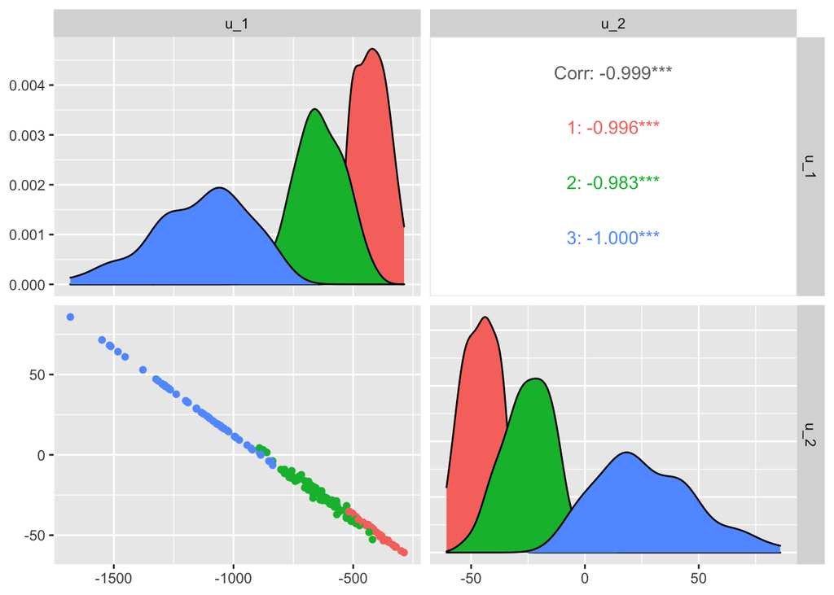

```r
plot_factors(model, type = "Umean")
```

The plot on the bottom left shows the clustering from the mcfa model. Next, we make a plot with the real labels shown:

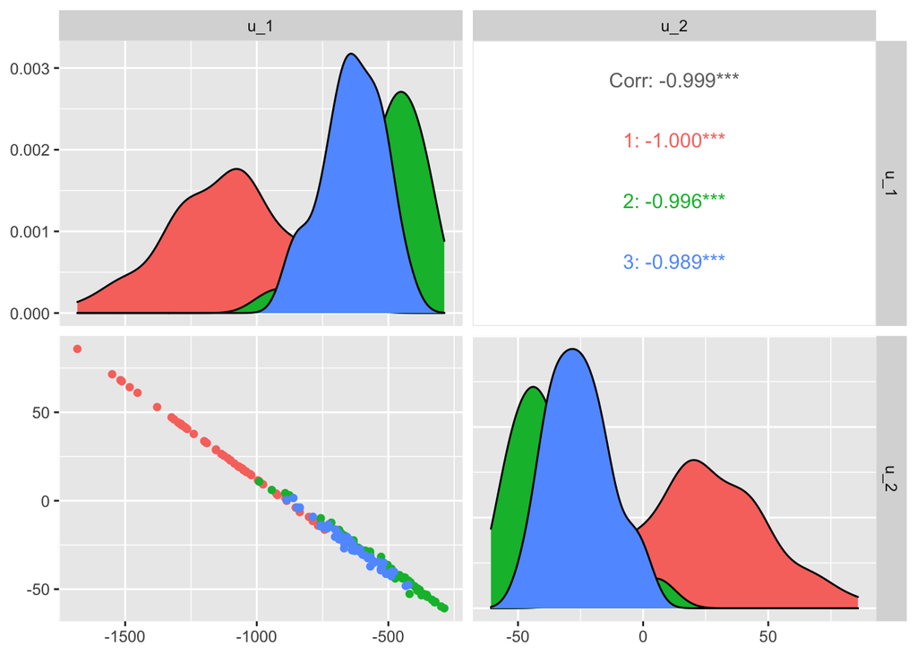

```r
plot_factors(model, type = "Umean", clust = wine$V1) #wine$V1 show real labels.
```

One can see from the plot above that that there are some misclassifications in our mcfa model, as some dots are classified with the wrong color compared to the real labelling.

## c)

### (i)

Now, the goal is to use PCA to reduce dimentionality before we fit a mixture model using Mclust. We use the PCA function from the FactoMineR-package.

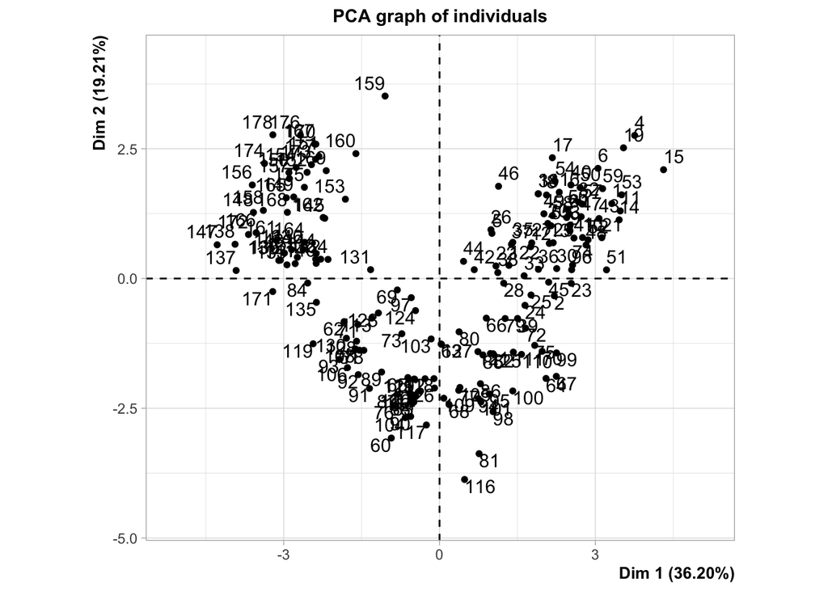

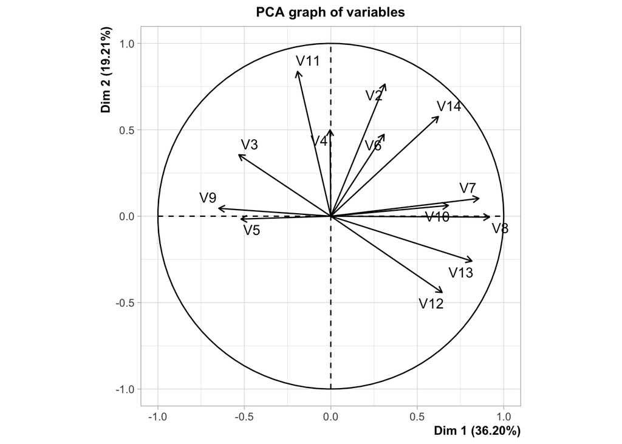

A visualization is shown below:

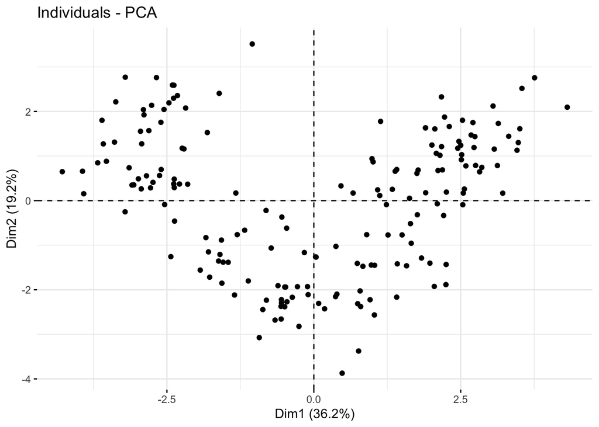

```r
fviz_pca_ind(pca.model, label = "none")
```

Now that we have our PC’s, we can fit our mixture model. The parameter values are shown below.

```r
mixture.pca <- Mclust(data = pca.data, G = 3)

mixture.pca$parameters
```

```
## $pro
## [1] 0.3783078 0.3485848 0.2731074
##
## $mean
##            [,1]       [,2]      [,3]
## Dim.1 2.2093513 -0.2415496 -2.752083
## Dim.2 0.7634274 -1.7812940  1.216084
##
## $variance
## $variance$modelName
## [1] "EEV"
##
## $variance$d
## [1] 2
##
## $variance$G
## [1] 3
##
## $variance$sigma
## , , 1
##
##           Dim.1     Dim.2
## Dim.1 0.6703286 0.3611780
## Dim.2 0.3611780 0.8666074
##
## , , 2
##
##            Dim.1      Dim.2
## Dim.1  1.0880853 -0.1947453
## Dim.2 -0.1947453  0.4488507
##
## , , 3
##
##           Dim.1     Dim.2
## Dim.1 0.4449628 0.1882162
## Dim.2 0.1882162 1.0919732
##
##
## $variance$scale
## [1] 0.6711648
##
## $variance$shape
## [1] 1.7026249 0.5873284
##
## $variance$orientation
## , , 1
##
##           Dim.1      Dim.2
## Dim.1 0.6073661  0.7944221
## Dim.2 0.7944221 -0.6073661
##
## , , 2
##
##            Dim.1      Dim.2
## Dim.1 -0.9627996 -0.2702163
## Dim.2  0.2702163 -0.9627996
##
## , , 3
##
##            Dim.1      Dim.2
## Dim.1 -0.2604283 -0.9654932
## Dim.2 -0.9654932  0.2604283
```

### (ii) Misclassification rate:

We can plot the misclassification rate, like we did in b(ii):

```r
classError(mixture.pca$classification, wine$V1)$errorRate
```

```
## [1] 0.04494382
```

### (iii)

Now we compare the PC-method to the mcfa by plotting both. Each point show the true class of origin.

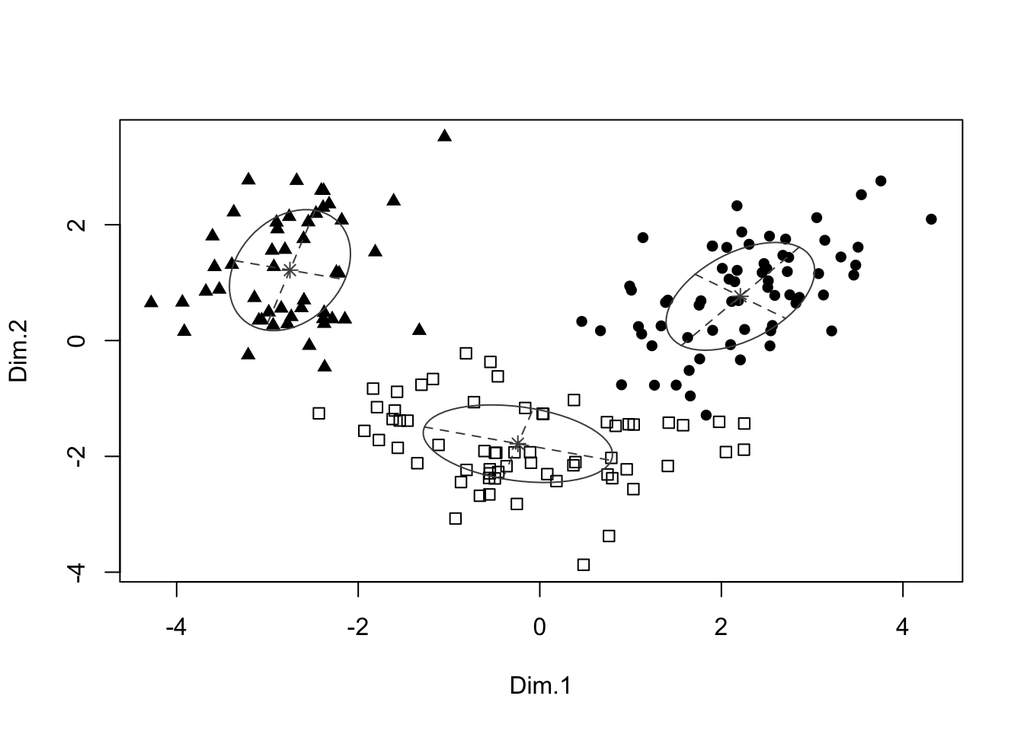

```r
plot(mixture.pca, what = "classification", col = wine$V1)
```

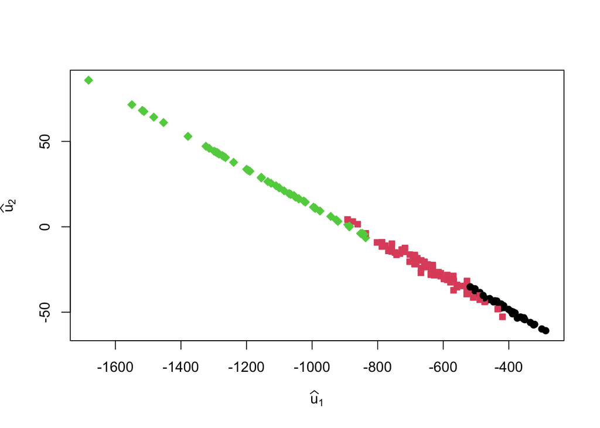

```r
plot(model, col = wine$V1)
```